# Clinic laboratory diagnostic. HW1

Liliya

2023-01-21

# ROC-анализ для дата-сета пациентов с диабетом и контрольной группой

Загрузим данные:

```r
data <- read.csv('diabetes.csv')
data %>% glimpse()
```

```
## Rows: 768
## Columns: 9
## $ Pregnancies              <int> 6, 1, 8, 1, 0, 5, 3, 10, 2, 8, 4, 10, 10, 1, …
## $ Glucose                  <int> 148, 85, 183, 89, 137, 116, 78, 115, 197, 125…
## $ BloodPressure            <int> 72, 66, 64, 66, 40, 74, 50, 0, 70, 96, 92, 74…
## $ SkinThickness            <int> 35, 29, 0, 23, 35, 0, 32, 0, 45, 0, 0, 0, 0, …
## $ Insulin                  <int> 0, 0, 0, 94, 168, 0, 88, 0, 543, 0, 0, 0, 0, …
## $ BMI                      <dbl> 33.6, 26.6, 23.3, 28.1, 43.1, 25.6, 31.0, 35.…
## $ DiabetesPedigreeFunction <dbl> 0.627, 0.351, 0.672, 0.167, 2.288, 0.201, 0.2…
## $ Age                      <int> 50, 31, 32, 21, 33, 30, 26, 29, 53, 54, 30, 3…
## $ Outcome                  <int> 1, 0, 1, 0, 1, 0, 1, 0, 1, 1, 0, 1, 0, 1, 1, …
```

```r
write.xlsx(data, "diabetes.xlsx", colnames = TRUE, rowNames = TRUE, append = TRUE)
```

Скорректируем переменные, которые должны быть факторами:

```r
data <- data %>%
    mutate(across(Outcome, ~ as.factor(.x)))

data %>% glimpse()
```

```
## Rows: 768
## Columns: 9
## $ Pregnancies              <int> 6, 1, 8, 1, 0, 5, 3, 10, 2, 8, 4, 10, 10, 1, …
## $ Glucose                  <int> 148, 85, 183, 89, 137, 116, 78, 115, 197, 125…
## $ BloodPressure            <int> 72, 66, 64, 66, 40, 74, 50, 0, 70, 96, 92, 74…
## $ SkinThickness            <int> 35, 29, 0, 23, 35, 0, 32, 0, 45, 0, 0, 0, 0, …
## $ Insulin                  <int> 0, 0, 0, 94, 168, 0, 88, 0, 543, 0, 0, 0, 0, …
## $ BMI                      <dbl> 33.6, 26.6, 23.3, 28.1, 43.1, 25.6, 31.0, 35.…
## $ DiabetesPedigreeFunction <dbl> 0.627, 0.351, 0.672, 0.167, 2.288, 0.201, 0.2…
## $ Age                      <int> 50, 31, 32, 21, 33, 30, 26, 29, 53, 54, 30, 3…
## $ Outcome                  <fct> 1, 0, 1, 0, 1, 0, 1, 0, 1, 1, 0, 1, 0, 1, 1, …
```

Проверим данные на наличие некорректных значений: NA или 0.

```r
#Проверка на наличие NA:
apply(data,2, function(x) is.na(x))
```

[output not shown]

[output cut: 1523 more lines]

```r
#Вывод: NA в дата-фрейме нет.
```

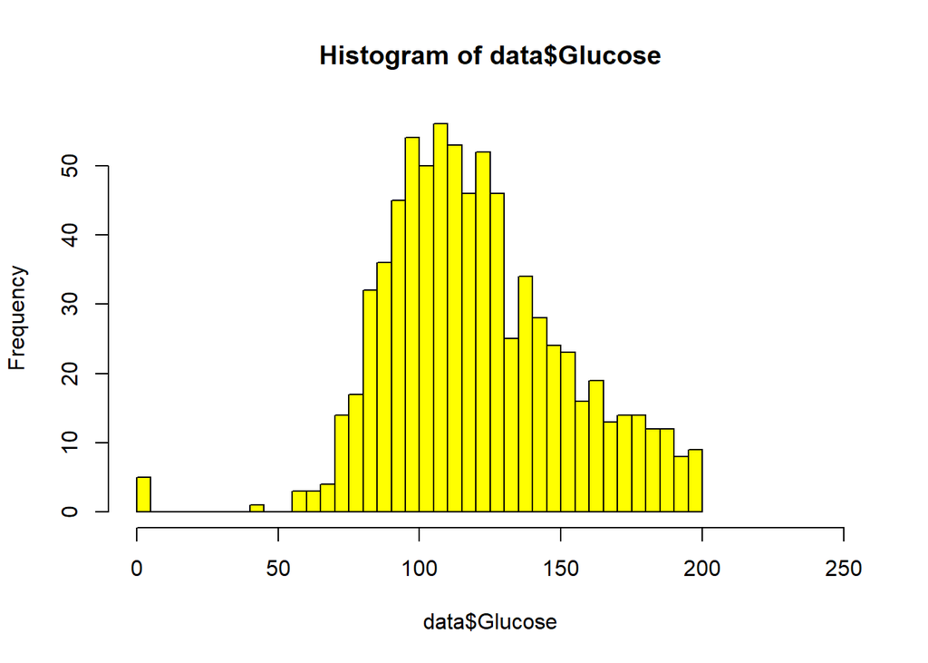

```r
# Проверка на наличие нулевых значений в переменных, где их быть не должно
# Построим гистограмму для оценки распределения значений в переменных:
hist(data$Glucose, col = 'yellow', xlim = c(0, 250), breaks = 50)
```

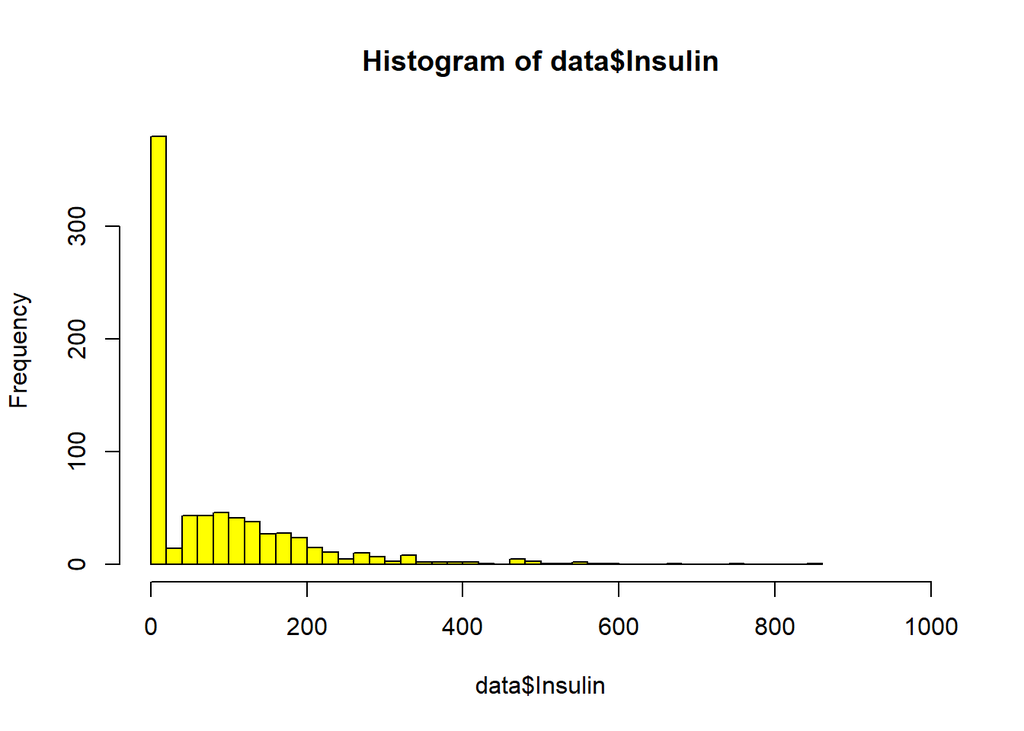

```r
hist(data$Insulin, col = 'yellow', xlim = c(0, 1000), breaks = 50)
```

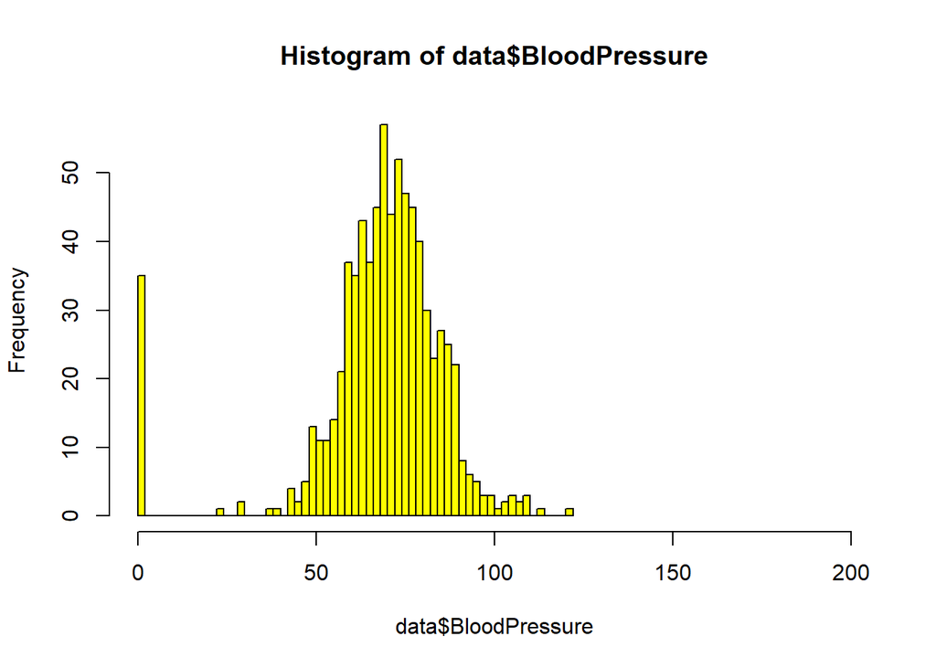

```r
hist(data$BloodPressure, col = 'yellow', xlim = c(0, 200), breaks = 50)
```

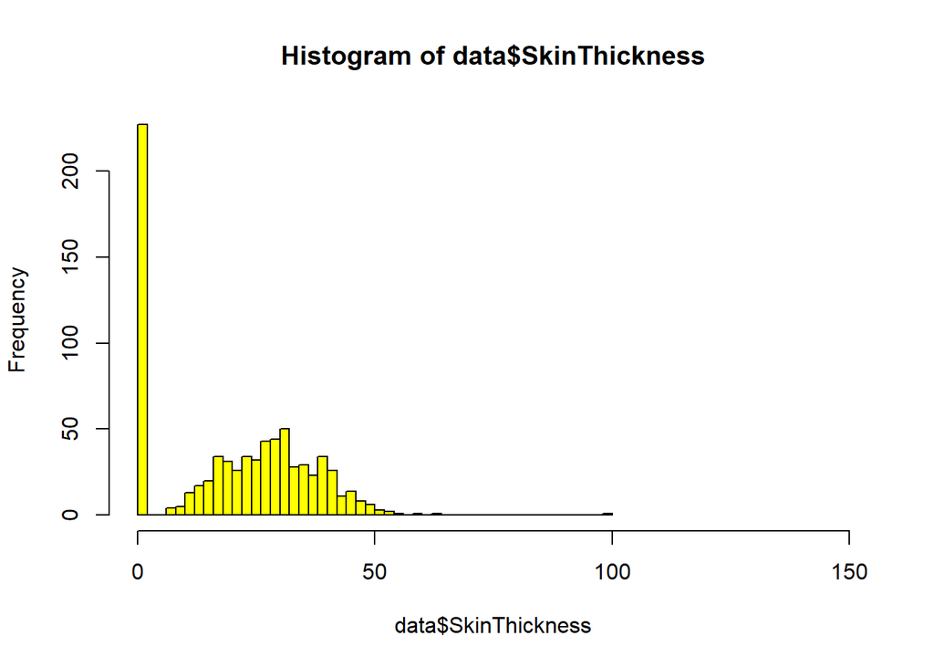

```r
hist(data$SkinThickness, col = 'yellow', xlim = c(0, 150), breaks = 50)
```

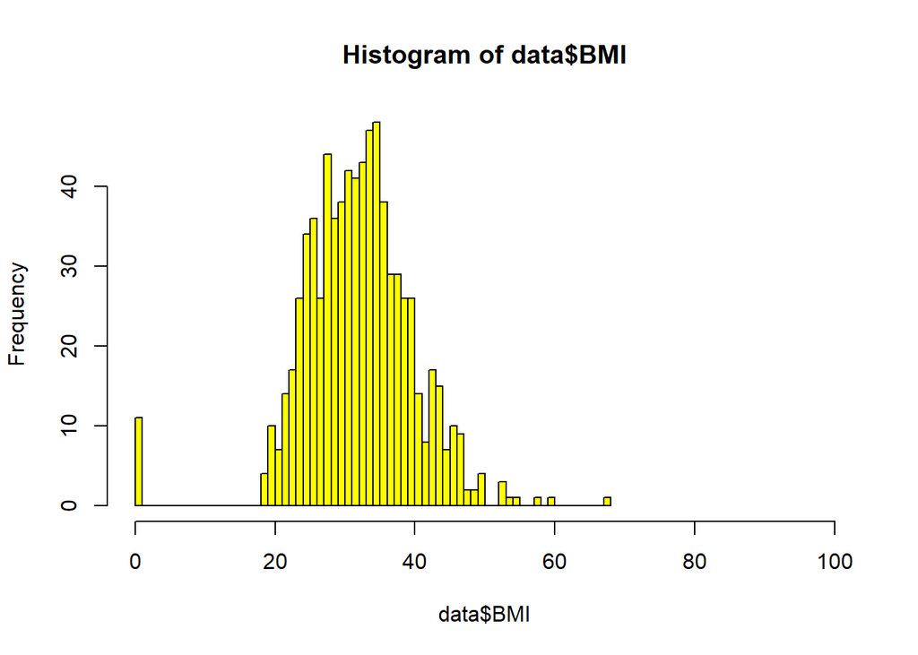

```r
hist(data$BMI, col = 'yellow', xlim = c(0, 100), breaks = 50)
```

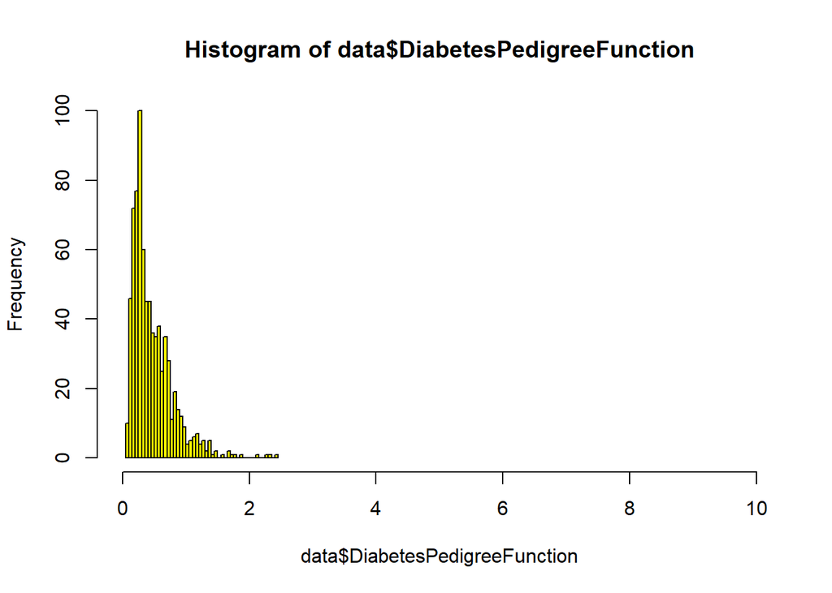

```r
hist(data$DiabetesPedigreeFunction, col = 'yellow', xlim = c(0, 10), breaks = 50)
```

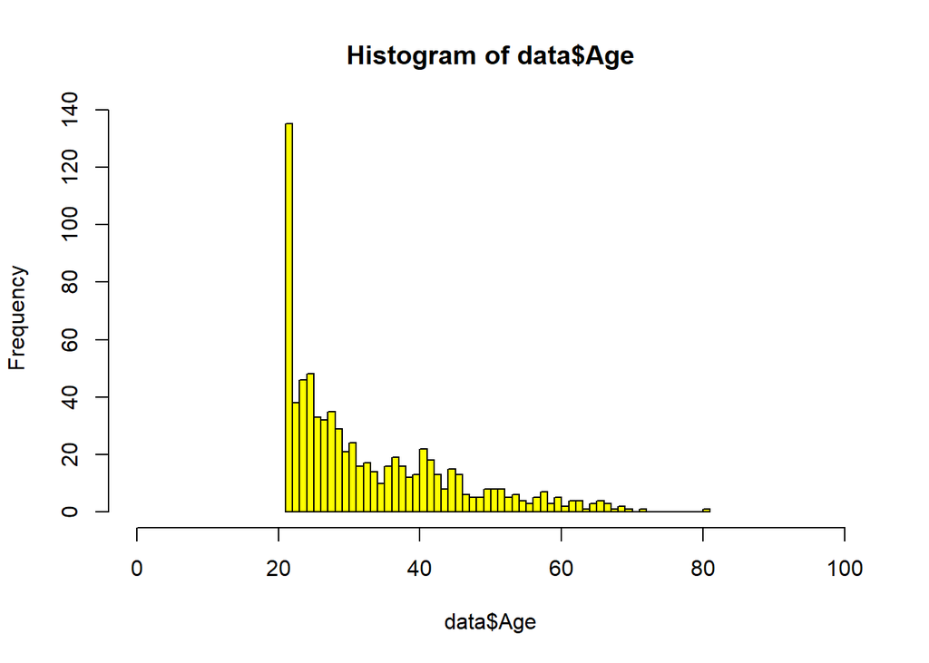

```r
hist(data$Age, col = 'yellow', xlim = c(0, 100), breaks = 50)
```

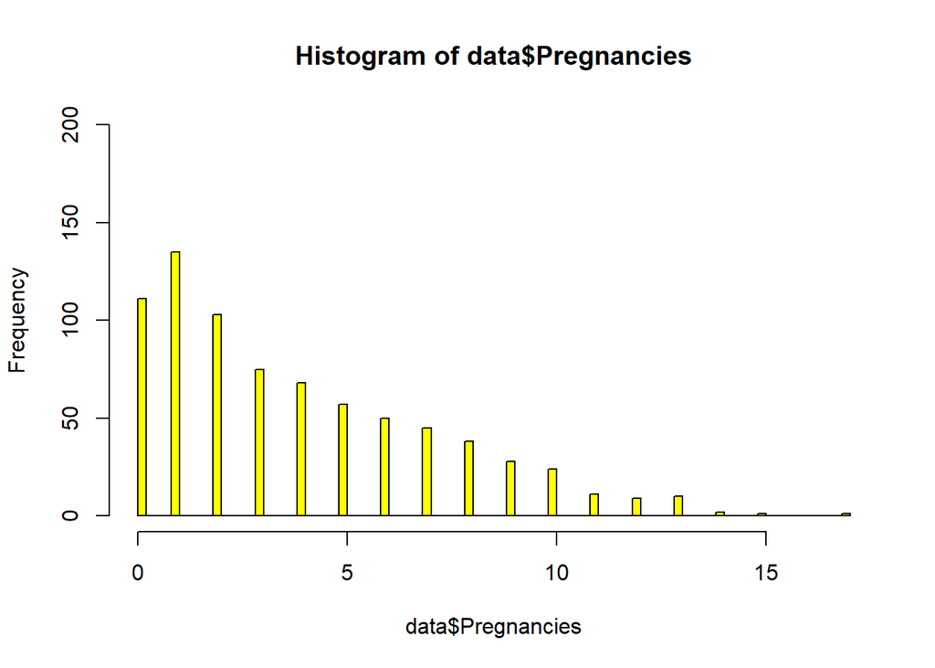

```r
hist(data$Pregnancies, col = 'yellow', ylim = c(0, 200), breaks = 100)
```

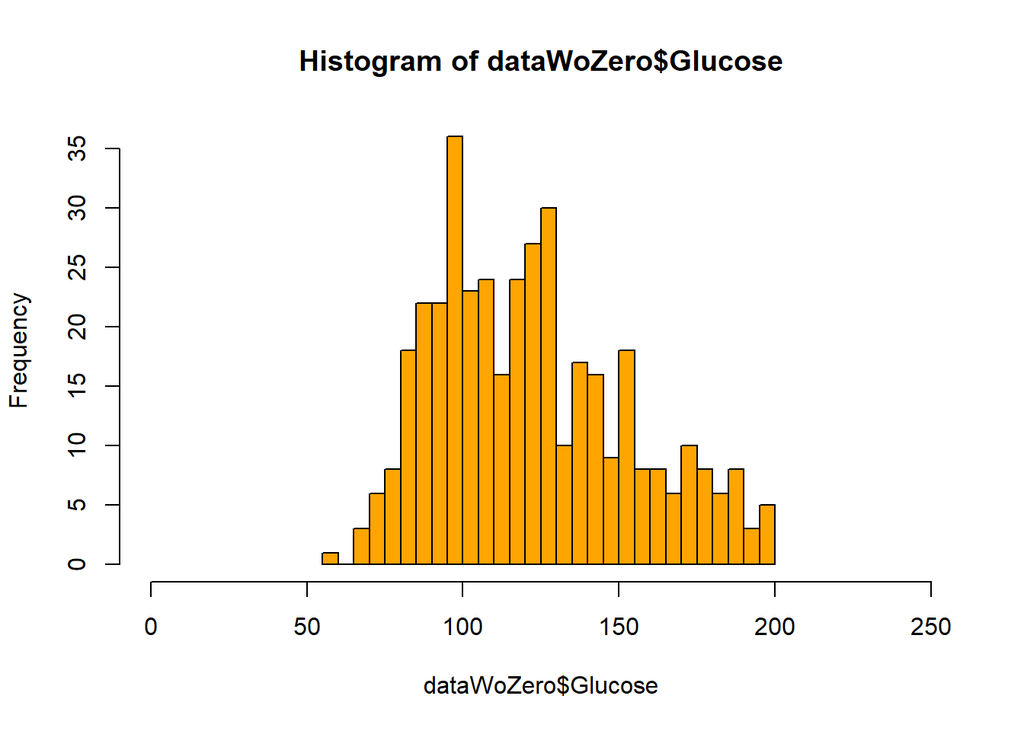

```r
# Фильтр нулевых значений
dataWoZero <- filter(data, Glucose > 0, Insulin > 0, BloodPressure > 0, SkinThickness > 0, BMI > 0)

# Построим графики для проверки выполненной фильтрации.
# Оранжевые графики - данные отфильтрованы, > 0.
# Желтые графики - фильтр не применялся.
hist(dataWoZero$Glucose, col = 'orange', xlim = c(0, 250), breaks = 50)
```

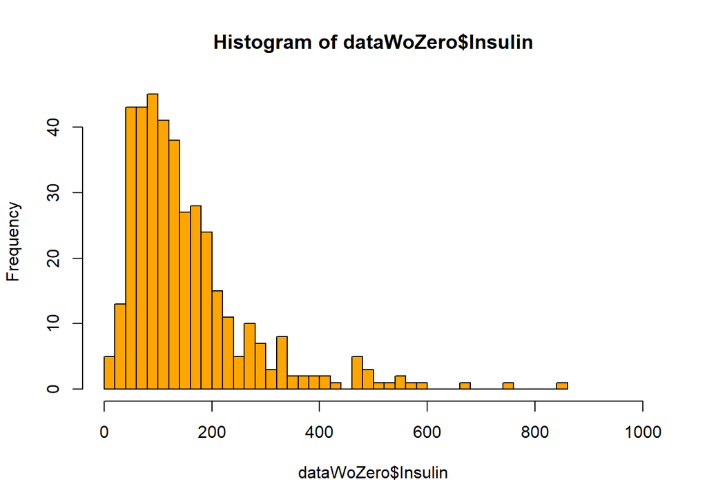

```r
hist(dataWoZero$Insulin, col = 'orange', xlim = c(0, 1000), breaks = 50)
```

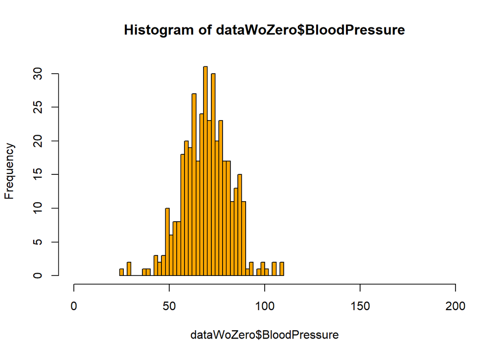

```r
hist(dataWoZero$BloodPressure, col = 'orange', xlim = c(0, 200), breaks = 50)
```

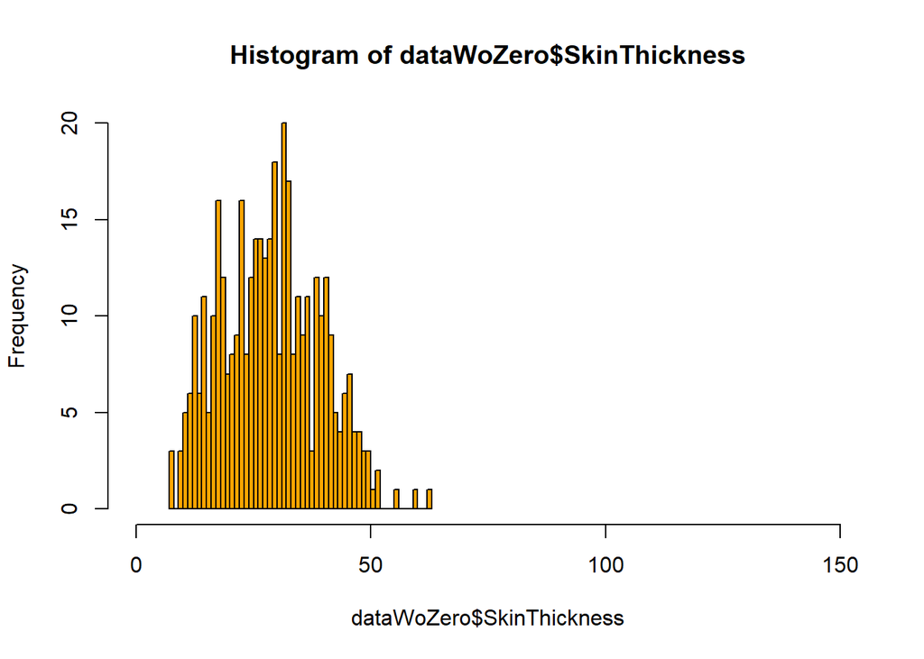

```r
hist(dataWoZero$SkinThickness, col = 'orange', xlim = c(0, 150), breaks = 50)
```

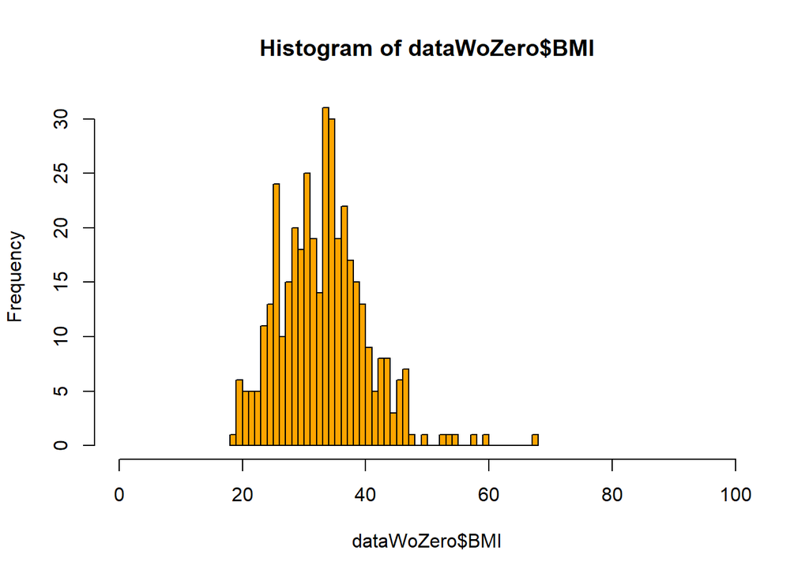

```r
hist(dataWoZero$BMI, col = 'orange', xlim = c(0, 100), breaks = 50)
```

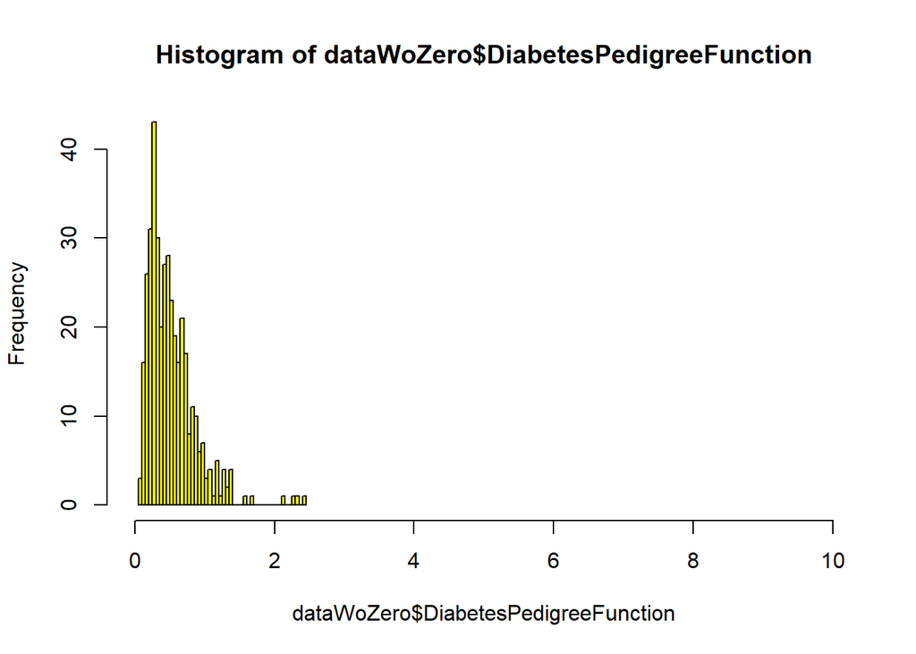

```r
hist(dataWoZero$DiabetesPedigreeFunction, col = 'yellow', xlim = c(0, 10), breaks = 50)
```

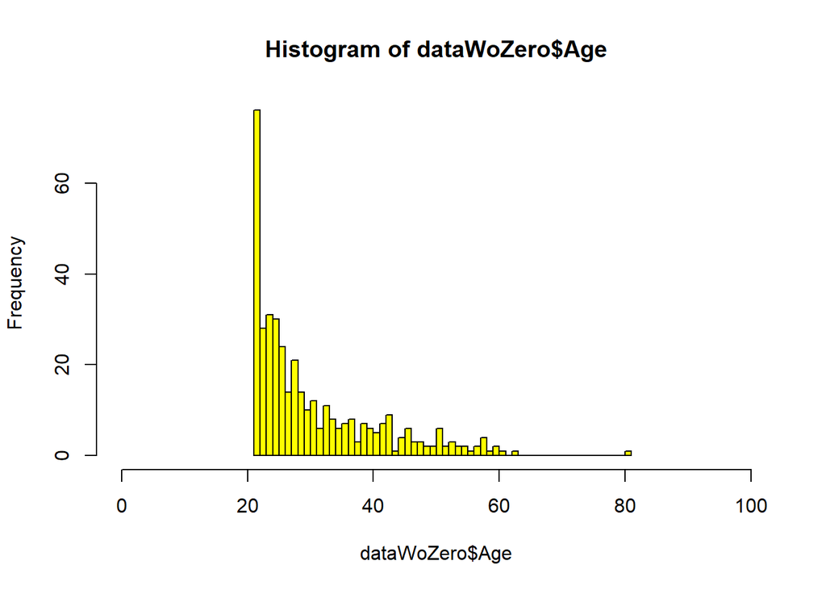

```r
hist(dataWoZero$Age, col = 'yellow', xlim = c(0, 100), breaks = 50)
```

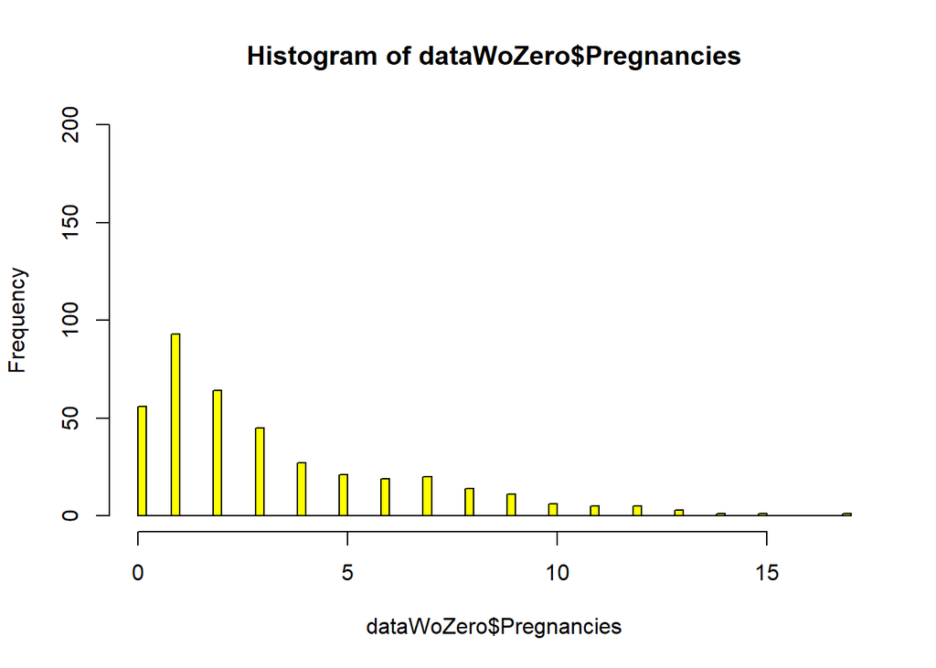

```r
hist(dataWoZero$Pregnancies, col = 'yellow', ylim = c(0, 200), breaks = 100)
```

### 1. Оценка НТГ

У какого количества пациентов из датасета присутствует нарушенная толерантность к глюкозе (НТГ)? Критерий НТГ – это уровень повышение гликемии ≥ 7.8 ммоль/л на 120 минуте теста на толерантность к глюкозе. Сколько в датасете пациентов, у которых нет НТГ?

```r
#Glucose
#1 ммоль/л = 18 мг/дл
#7.8 ммоль/л = 140,4 мг/дл

dataWoZero <- dataWoZero %>%
  mutate(ID = row_number())
ntg.high.n <- 0

for (i in 1:(length(dataWoZero$ID))){
  if (dataWoZero$Glucose[i] > 140.4){
    ntg.high.n <- ntg.high.n + 1
  }
}
paste("У", ntg.high.n, "пациентов из датасета присутствует нарушенная толерантность к глюкозе (НТГ)")
```

```
## [1] "У 105 пациентов из датасета присутствует нарушенная толерантность к глюкозе (НТГ)"
```

```r
ntg.zero.n <- 0
for (i in 1:(length(dataWoZero$ID))){
  if (dataWoZero$Glucose[i] < 140.4){
    ntg.zero.n <- ntg.zero.n + 1
  }
}
paste("У", ntg.zero.n, "пациентов из датасета не нарушена толерантность к глюкозе (НТГ)")
```

```
## [1] "У 287 пациентов из датасета не нарушена толерантность к глюкозе (НТГ)"
```

Сделаем описательную статистику и сравним группы между собой:

```r
dataWoZero %>%
    select(!ID) %>%
    tbl_summary(by = Outcome) %>%
    add_p()
```

| **Characteristic** | **0**, N = 262<sup>1</sup> | **1**, N = 130<sup>1</sup> | **p-value**<sup>2</sup> |
| --- | --- | --- | --- |
| Pregnancies | 2 (1, 4) | 3 (1, 7) | <0.001 |
| Glucose | 108 (94, 126) | 144 (124, 172) | <0.001 |
| BloodPressure | 70 (60, 76) | 74 (66, 82) | <0.001 |
| SkinThickness | 27 (18, 34) | 33 (26, 40) | <0.001 |
| Insulin | 105 (66, 164) | 170 (128, 239) | <0.001 |
| BMI | 31 (26, 36) | 35 (32, 38) | <0.001 |
| DiabetesPedigreeFunction | 0.41 (0.26, 0.62) | 0.55 (0.33, 0.79) | <0.001 |
| Age | 25 (22, 30) | 33 (27, 43) | <0.001 |

<sup>1</sup> Median (IQR)  
<sup>2</sup> Wilcoxon rank sum test

### 2. Построение ROC-кривой для предсказания сахарного диабета по уровню гликемии

Построим график ROC-кривой для предсказания сахарного диабета по переменной, характеризующей уровень гликемии:

```r
roc_curve <- roc(data = dataWoZero, response = Outcome, predictor = Glucose, ci = T, direction = "<")
roc_curve
```

```
##
## Call:
## roc.data.frame(data = dataWoZero, response = Outcome, predictor = Glucose,     ci = T, direction = "<")
##
## Data: Glucose in 262 controls (Outcome 0) < 130 cases (Outcome 1).
## Area under the curve: 0.8058
## 95% CI: 0.7594-0.8521 (DeLong)
```

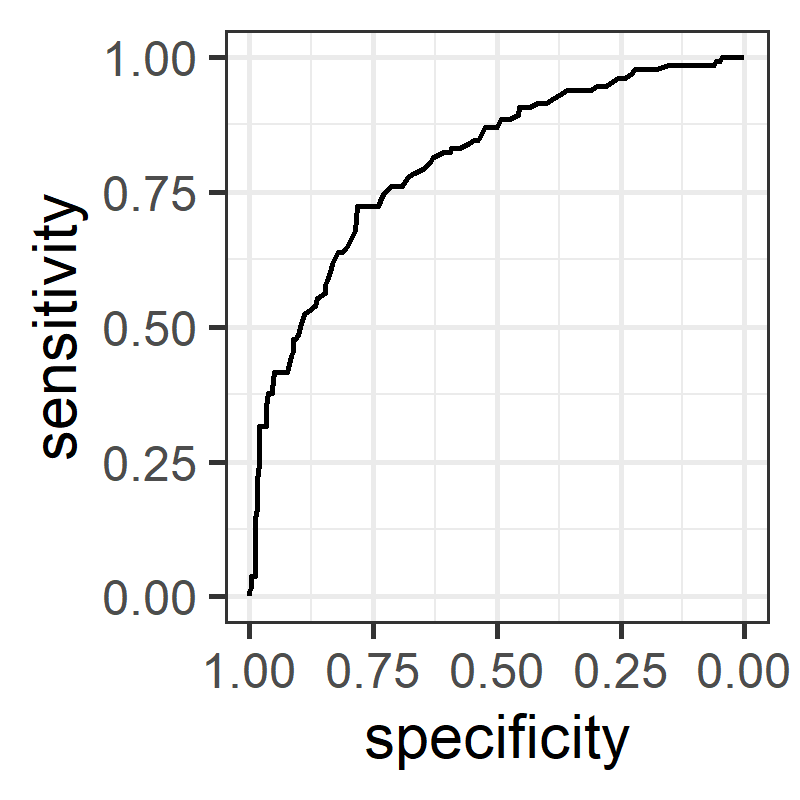

```r
ggroc(roc_curve) +
    theme_bw()
```

#### (3) Площадь под ROC-кривой составляет 0.8058.

#### (4) 95% двусторонний ДИ для площади под ROC-кривой: 0.7594-0.8521

#### (5) Выбор порогового значения для ROC-кривой

```r
roc_curve %>% coords
```

| threshold | specificity | sensitivity |
| --- | --- | --- |
| -Inf | 0.000000000 | 1.000000000 |
| 62.0 | 0.003816794 | 1.000000000 |
| 69.5 | 0.015267176 | 1.000000000 |
| 72.5 | 0.022900763 | 1.000000000 |
| 74.5 | 0.034351145 | 1.000000000 |
| 76.0 | 0.038167939 | 1.000000000 |
| 77.5 | 0.045801527 | 1.000000000 |
| 78.5 | 0.049618321 | 0.992307692 |
| 79.5 | 0.057251908 | 0.992307692 |
| 80.5 | 0.061068702 | 0.984615385 |

[output cut: 108 more lines]

```r
roc_curve %>% coords(x = "best", best.method = "closest.topleft")
```

| threshold | specificity | sensitivity |
| --- | --- | --- |
| 127.5 | 0.7824427 | 0.7230769 |

```r
#closest.topleft - метод "ближайший к углу"
```

#### (6) Какая из количественных переменных в датасете обладает наибольшей площадью под ROC-кривой? Какая количественная переменная имеет наименьшую площадь?

```r
dataWoZero %>%
    select(!ID) %>%
    pivot_longer(cols = !Outcome) %>%
    group_by(name) %>%
    summarise(AUC = roc(Outcome, value, ci = T, direction = "<")$ci[2] %>% round(3),
              AUC_LCL = roc(Outcome, value, ci = T, direction = "<")$ci[1] %>% round(3),
              AUC_UCL = roc(Outcome, value, ci = T, direction = "<")$ci[3] %>% round(3))
```

| name | AUC | AUC_LCL | AUC_UCL |
| --- | --- | --- | --- |
| Age | 0.743 | 0.693 | 0.794 |
| BloodPressure | 0.621 | 0.562 | 0.680 |
| BMI | 0.664 | 0.610 | 0.718 |
| DiabetesPedigreeFunction | 0.622 | 0.562 | 0.681 |
| Glucose | 0.806 | 0.759 | 0.852 |
| Insulin | 0.730 | 0.679 | 0.781 |
| Pregnancies | 0.621 | 0.559 | 0.684 |
| SkinThickness | 0.659 | 0.604 | 0.715 |

*Примечание:*  
- `AUC` - площадь под ROC-кривой;  
- `AUC_LCL` - нижняя граница ДИ;  
- `AUC_UCL` - верхняя граница ДИ.

#### Интерпретация результата

1. AUC - Area under ROC curve, площадь под ROC кривой. Чем выше значение - тем лучше, 0.5 - случайная диагностика, не отличающаяся от равновероятностной, больше 0.80 - считается хорошая классификация.
2. Наибольшей диагностической информативностью обладает показатель Glucose (AUC=0.806), уровень глюкозы на 120 минуте орального глюкозотолерантного теста (мг/дл).
3. Наименьшей диагностической информативностью обладает показатель BloodPressure (диастолическое артериальное давление), AUC=0.621 и Pregnancies (количество беременностей в анамнезе), AUC=0.621.